# Pretest Results: CIG Hydrolytic Extracelleular Enzyme Assays

Hava Blair

July 1, 2020

# About the pre-test 2 samples

SW1_SH_A_3 = MN River Valley, pH 6.5  
RRV2_SH_A_3 = Red River Valley, pH 8

I performed the pre-test on these samples using buffers at the soil pH for that sample (6.5 or 8). I also tested both samples with a neutral (7) buffer.

# Pre-test data

Pre-test data was processed with the R-Markdown document “eea_pretest_calcs.Rmd”

```
##          plate conc_uM ph_buffer  sample_id enzyme  activity
## 1 1-rr120-8-bc   150.0         8 RR2_SH_A_3     BG 42.002512
## 2 1-rr120-8-bc   150.0         8 RR2_SH_A_3  Cello  2.706578
## 3 1-rr120-8-bc    18.6         8 RR2_SH_A_3     BG 35.367427
## 4 1-rr120-8-bc    18.6         8 RR2_SH_A_3  Cello  4.062203
## 5 1-rr120-8-bc   210.0         8 RR2_SH_A_3     BG 50.279287
## 6 1-rr120-8-bc   210.0         8 RR2_SH_A_3  Cello  4.065766
```

# Phosphatase

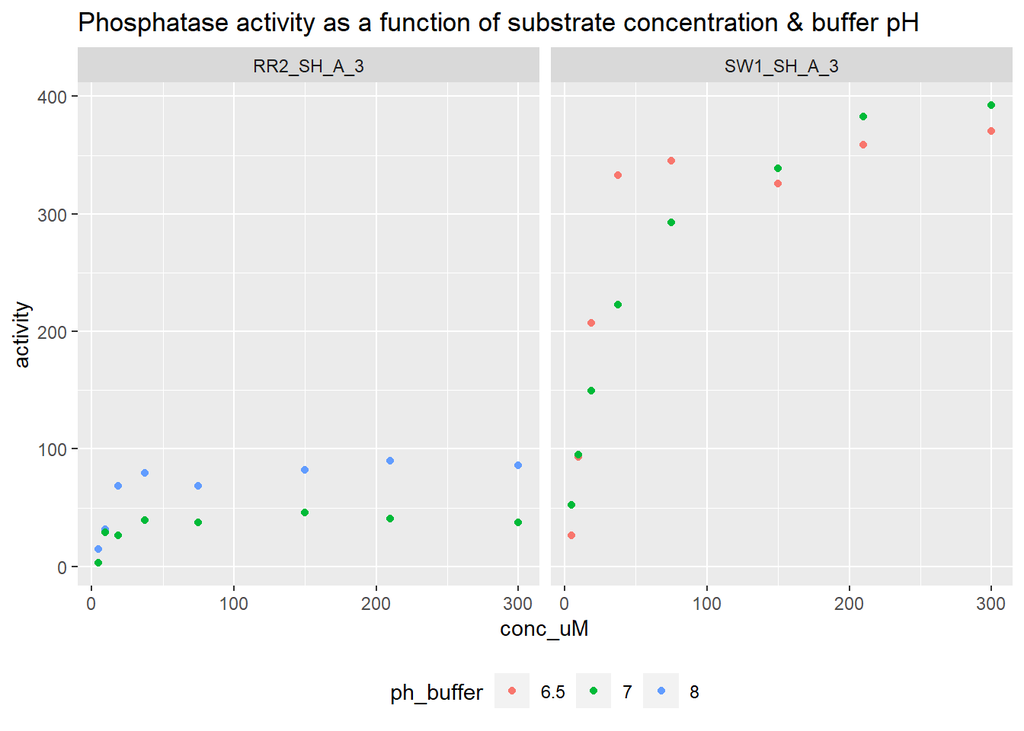

## Red River Valley

At pH 7, we appear to have saturating substrate concentrations starting around ~ 75 uM, similar to pre-test 1. At substrate concentrations of 300uM, activity for pH 8 is ~90, while at pH 7 it is ~40 (~45% difference)

## MN River Valley

Activities are similar for both pH 6.5 and pH 7. Appear to reach saturation at >210uM substrate concentration.

# N-acetylglucosaminidase (NAGase)

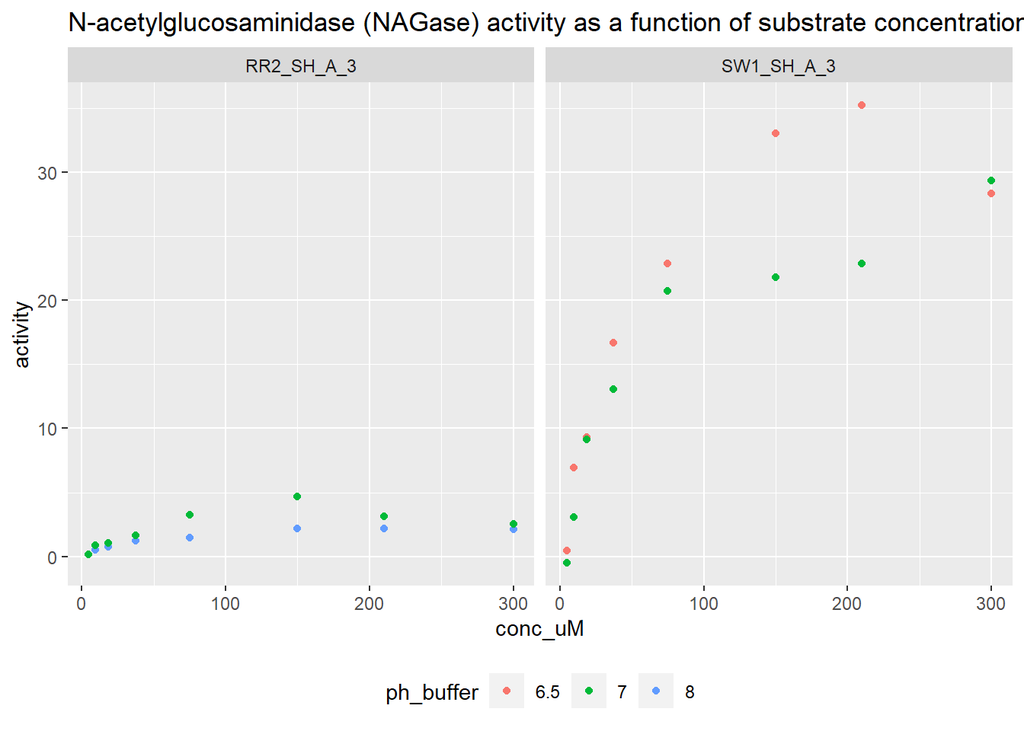

## Red River Valley

Substantially lower activity in the RR sample compared to the SW sample. But activities at pH 7 vs pH 8 for this sample are pretty similar

## MN River Valley

Activities at pH 6.5 is substantially higher at substrate concentrations 150uM and 210uM. However at 300uM activites are simlar for pH 6.5 and 7.

# Cellobiohydrolase

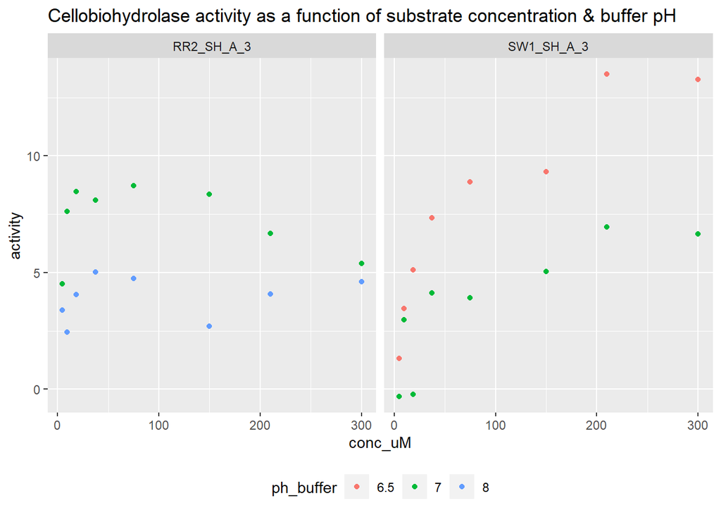

## Red River Valley

Somewhat perplexing curve shape here - looks like activities peek around 75-100uM and then decline >150uM for both pHs?

## MN River Valley

Activity consistently higher at pH 6.5 compared to pH 7 except at the lowest substrate concentrations. At 300uM, our typical “saturating” condition for these assays, activity at pH 6.5 is ~13, while at pH 7 it is ~7.

# B-glucosidase

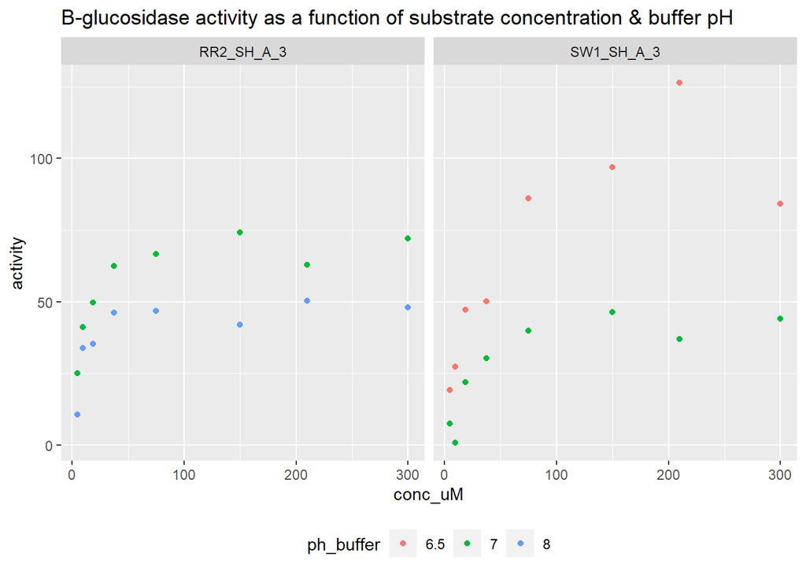

## Red River Valley

Activities consistently higher at pH 7 than at pH 8. At 300uM activity at pH 7 is ~75, while at pH 8 it is 45.

## SW (MN River Valley)

Activity consistently higher at pH 6.5 than at pH 7.

At pH 7, we appear to reach saturating substrate concentrations at >150uM.

# Overall

For NAG, the change in buffer pH does not appear to have a big impact on actvity measured at substrate concentrations of 300uM for either RR or SW samples.

BG activity - pH makes a big difference (50%+) in activity for both samples

Cello activity - at substrate concentrations of 300uM, not much difference in activity for the RR2 sample between pH 7 and 8, but the curve shape overall looks a bit weird. For the SW sample, activity is ~50% at pH 6.5.